# LIONESS Network Analysis

Author

João V. F. Cavalcante

## Methodology

The analytical pipeline strictly adhered to the following steps:

- **Network Construction**: Single-sample networks (SSNs) were reverse-engineered from aggregate networks using the **LIONESS** method.
- **STRING Validation**: SSNs were intersected with experimentally confirmed protein-protein interactions (PPI) from the STRING database to ensure biological reliability.
- **Topological Feature Extraction**: The degree (number of connections) was calculated as a node feature for each gene in every individual SSN.
- **Statistical Identification**: A two-sided T-test was conducted on the degree vectors to identify **DIGs** ($padj < 0.05$ after BH correction).
- **Normalization**: Degree matrices were normalized via scaling factors and log-transformed to stabilize variance before visualization.

## Results

### Dimensionality Reduction (Network Topology)

To observe the global distribution of gene interaction patterns, we performed PCA and UMAP on the normalized degree matrix. We retained genes with a standard deviation (SD) > 1.

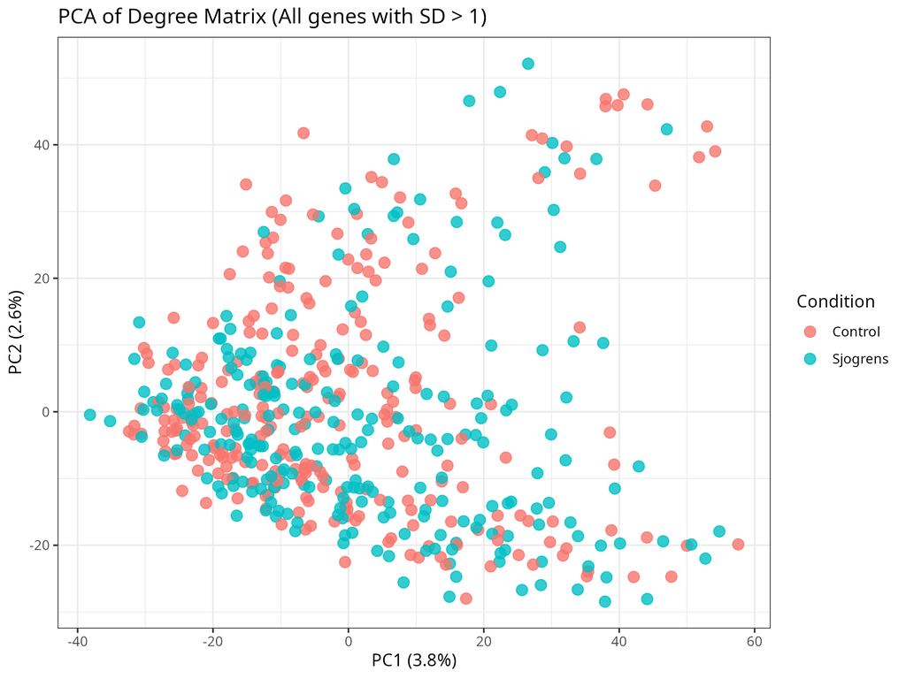

PCA: Global Interaction Patterns

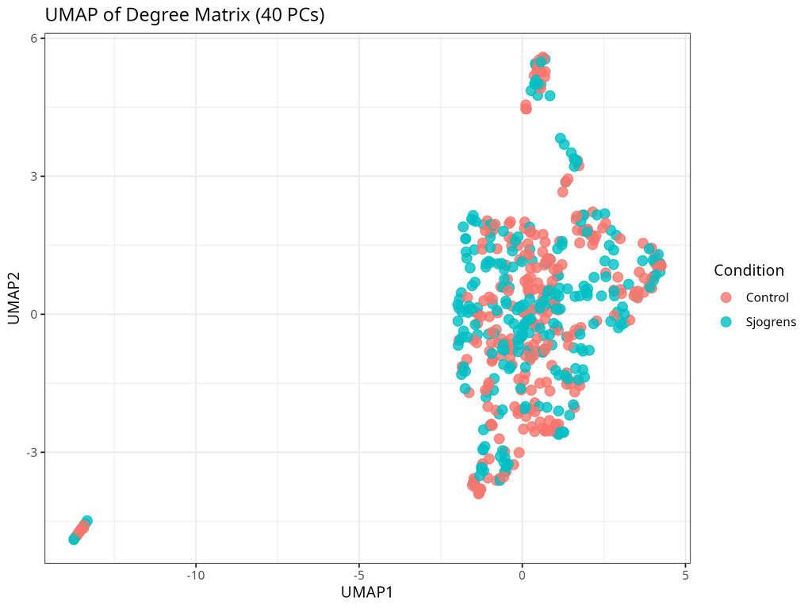

UMAP: Global Interaction Patterns

### Differentially Interacted Genes (DIGs)

We identified genes that exhibited significant changes in their interaction patterns. The table below lists the top 10 genes most affected by condition-specific network rewiring.

Top 10 Hub DIGs by Connectivity Change

| symbol | gene | diff_deg | abs_diff |
| --- | --- | --- | --- |
| UTY | ENSG00000183878 | -145.32647 | 145.32647 |
| KDM6A | ENSG00000147050 | -115.63303 | 115.63303 |
| DDX3Y | ENSG00000067048 | -76.84246 | 76.84246 |
| ISG15 | ENSG00000187608 | 75.09691 | 75.09691 |
| AXL | ENSG00000167601 | 68.53772 | 68.53772 |
| OASL | ENSG00000135114 | 61.83570 | 61.83570 |
| HABP2 | ENSG00000148702 | 59.55831 | 59.55831 |
| ANK2 | ENSG00000145362 | -49.46875 | 49.46875 |
| RPS4Y1 | ENSG00000129824 | -49.00135 | 49.00135 |
| CUL1 | ENSG00000055130 | 48.90816 | 48.90816 |

**Interpretation**: A positive `diff_deg` indicates a gain of connectivity in the Sjogren’s group, while a negative value indicates a loss of interactions compared to ground controls.

### Functional Enrichment Analysis

#### GO Biological Processes

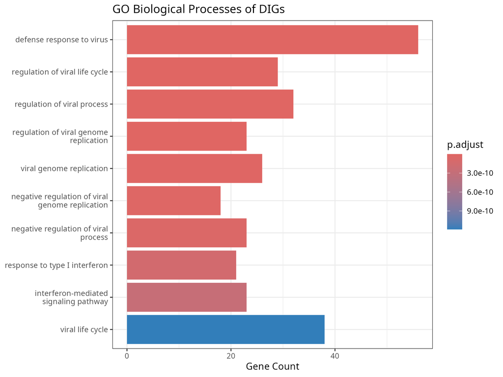

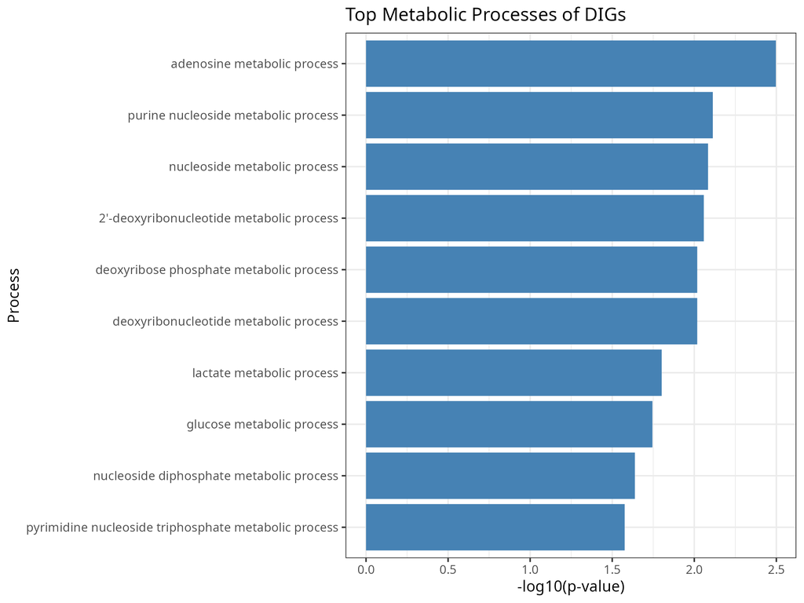

| Description | GeneRatio | p.adjust | Count |
| --- | --- | --- | --- |
| defense response to virus | 56/605 | 0 | 56 |
| regulation of viral life cycle | 29/605 | 0 | 29 |
| regulation of viral process | 32/605 | 0 | 32 |
| regulation of viral genome replication | 23/605 | 0 | 23 |
| viral genome replication | 26/605 | 0 | 26 |
| negative regulation of viral genome replication | 18/605 | 0 | 18 |
| negative regulation of viral process | 23/605 | 0 | 23 |
| response to type I interferon | 21/605 | 0 | 21 |
| interferon-mediated signaling pathway | 23/605 | 0 | 23 |
| viral life cycle | 38/605 | 0 | 38 |

#### KEGG Pathway Mapping

Top Enriched KEGG Pathways

| Description | p.adjust | geneID |
| --- | --- | --- |
| Epstein-Barr virus infection | 0.0000000 | 4939/4940/4938/5610/9636/23586/3627/1380/3111/29760/3112/958/930/3665/6773/6890/5608/841/2208/7188/6772/5701/4616/3120/8819/10213/956/5707/5295/596 |
| Influenza A | 0.0000000 | 4939/4940/64135/91543/4938/4599/5610/6347/23586/3627/3111/4600/3112/5371/3665/6773/51284/841/3838/3459/103/5594/6772/3717/3120/5295 |
| Herpes simplex virus 1 infection | 0.0000007 | 4939/4940/64135/4938/5610/6347/23586/6672/3111/3112/330/5371/3665/6773/6890/684/841/3459/7188/6772/3717/3120/5295/596 |
| Primary immunodeficiency | 0.0000245 | 29760/958/930/6890/115650/959/973/100/925/3575 |
| Measles | 0.0000368 | 4939/4940/64135/4938/4599/5610/23586/4600/940/3665/6773/51284/841/103/3559/6772/5295/596 |
| B cell receptor signaling pathway | 0.0000905 | 25780/1380/8519/29760/933/971/930/974/55024/118788/640/973/5594/5295 |
| Coronavirus disease - COVID-19 | 0.0001859 | 4939/4940/64135/4938/4599/5610/9636/6192/6347/23586/3627/4600/717/6773/51284/713/103/5594/5335/6772/714/712/5295 |
| Intestinal immune network for IgA production | 0.0001859 | 3111/3112/958/940/115650/959/608/6387/3120/56477 |
| Viral protein interaction with cytokine and cytokine receptor | 0.0001901 | 6347/10563/3627/1235/4283/6355/6373/6354/643/6357/1230/3559/6387/56477 |
| Chemokine signaling pathway | 0.0002152 | 6347/10563/3627/1235/4283/6355/6373/6354/6773/643/6357/2788/1230/5594/5335/6772/6387/3717/5295/56477 |